# Praca domowa nr 3

Martyna Majchrzak

15 04 2021

## Zbiór danych

Zbiór danych Diabetes zawiera informacje o osobach chorych na cukrzycę.

1. preg - ile razy dana osoba była w ciąży
2. plas - stężenie glukozy w osoczu po 2h ustnego testu na tolerancję glukozy
3. pres - ciśnienie rozkurczowe (mm Hg)
4. skin - grubość skóry mierzona na tricepsie (mm)
5. insu - 2-Hour serum insulin (mu U/ml)
6. mass - index masy ciała BMI (waga w kg/(wzrost w m)^2)
7. pedi - obciążenie genetyczne (Diabetes pedigree function)
8. age - wiek (lata)
9. class - zmienna celu o wartościach tested_negative oraz tested_positive

## Rozkłady zmiennych

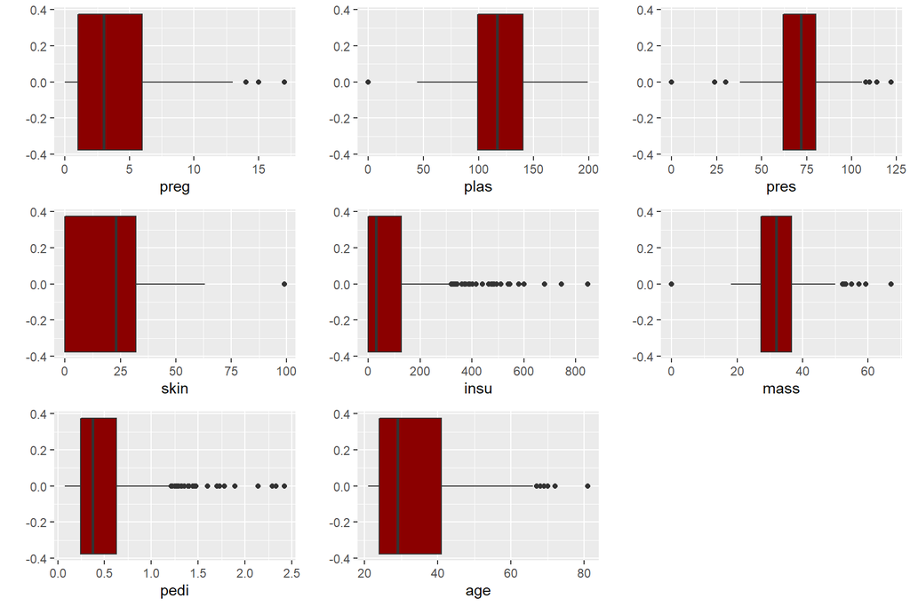

## Tworzenie modelu i explainera

W rozwiązaniu zostanie użyty model Random Forest. Według danych OpenML ( https://www.openml.org/t/37 ) osiąga on średnio największą wartość miary accuracy.

```
## Preparation of a new explainer is initiated
##   -> model label       :  ranger  (  default  )
##   -> data              :  768  rows  8  cols
##   -> target variable   :  768  values
##   -> predict function  :  yhat.ranger  will be used (  default  )
##   -> predicted values  :  No value for predict function target column. (  default  )
##   -> model_info        :  package ranger , ver. 0.12.1 , task classification (  default  )
##   -> predicted values  :  numerical, min =  0 , mean =  0.3491104 , max =  0.953319
##   -> residual function :  difference between y and yhat (  default  )
##   -> residuals         :  numerical, min =  -0.5822087 , mean =  -0.0001521111 , max =  0.6520325
##   A new explainer has been created!
```

## Predykcja dla obserwacji 13

Przyjrzyjmy się pacjentce ze szczęśliwym numerem 13.

|  | preg | plas | pres | skin | insu | mass | pedi | age | class |
| --- | --- | --- | --- | --- | --- | --- | --- | --- | --- |
| 12 | 10 | 139 | 80 | 0 | 0 | 27.1 | 1.441 | 57 | tested_negative |

Jest to 57-latka która była w ciąży 10 razy i ma BMI 27,1 (nadwaga).

```
##      tested_negative tested_positive
## [1,]       0.7534169       0.2465831
```

Ta osoba z prawdopodobieństwem ok. 0.75 została przypisana do klasy tested_negative (czyli 0.25 do tested_positive)

## Ceteris Paribus profile dla obserwacji 13

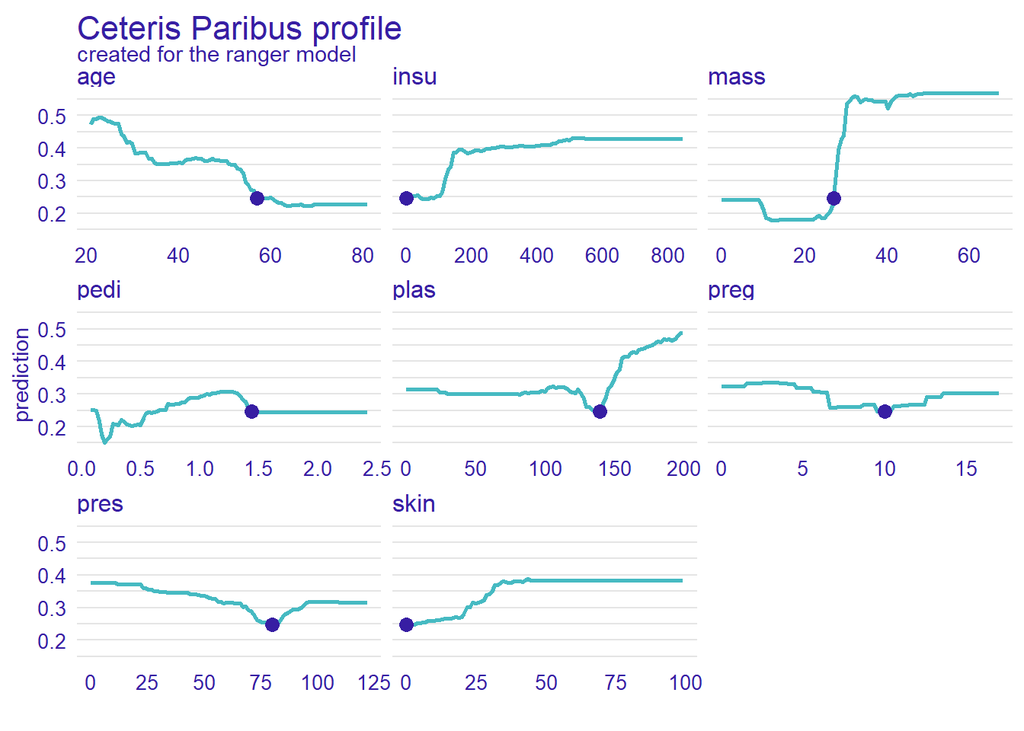

## Różnice w profilach pomiędzy obserwacjami

Przyjrzyjmy się profilom dla zmiennej `skin`, która do tej pory w eksperymentach nie wydawała się być zbyt istotna.

### Obserwacja 13

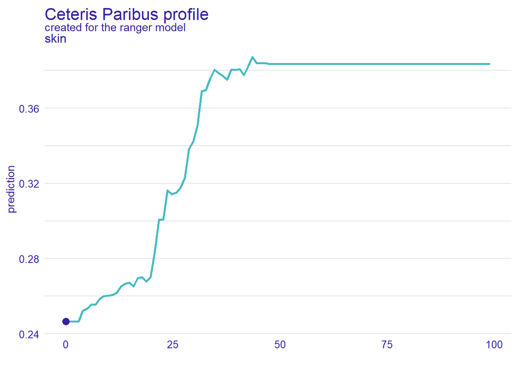

### Obserwacja 3

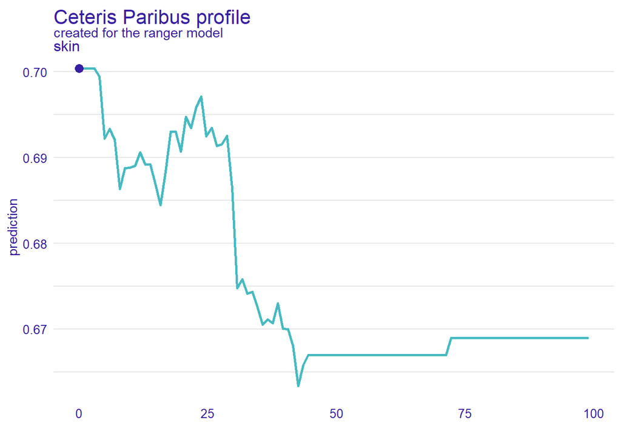

Dla 3 obserwacji im wyższa wartość zmiennej skin, tym niższa wartość predykcji. Predykcja zawiera się w przedziale (0,65-0.7) i prawdziwa jest wartośc największa - 0.7.

### Obserwacja 5

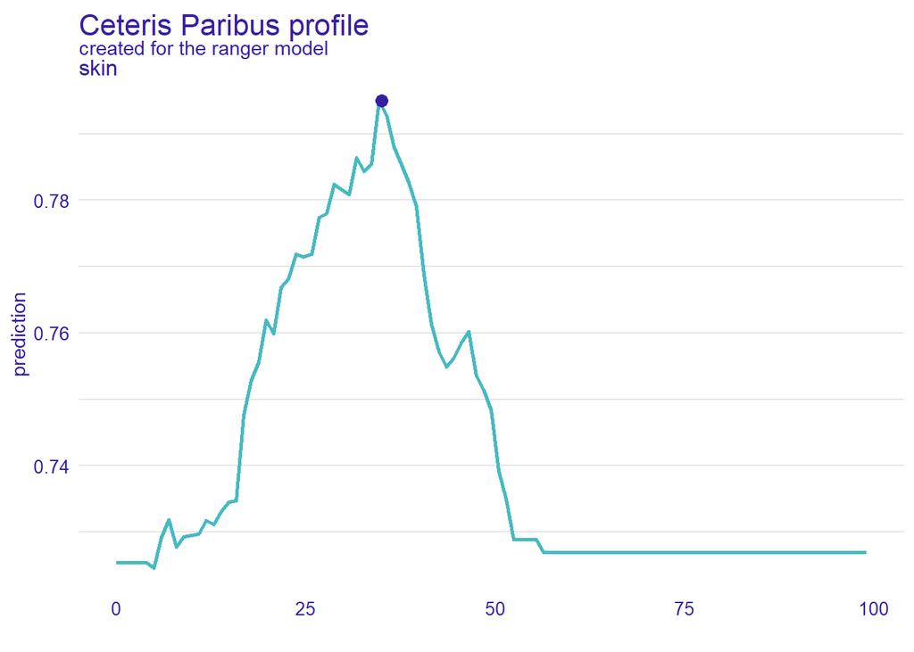

Dla 5 obserwacji mamy jeszcze inną sytuację - dla małych i dyżych wartości `skin` przewidywana jest niższa, choć nadal wysoka wartość (w okolicach 0.72), a dla 25<`skin`<40 mamy skok do wartość ok 0.8, która jest prawdziwą wartością predykcji.

### Obserwacja 1

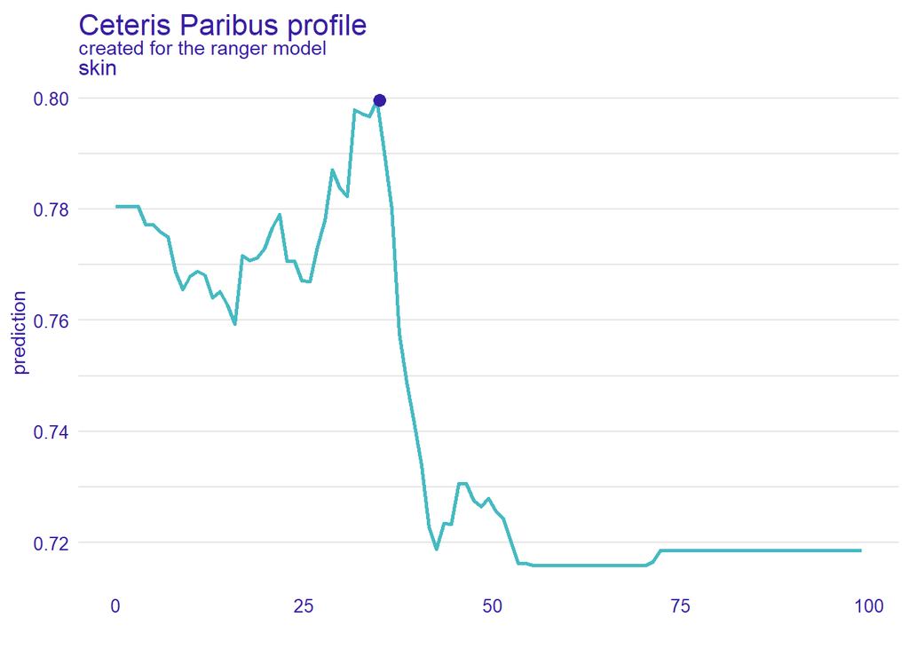

Dla 1 obserwacji mamy podobną sytuację - dla małych i dyżych wartości `skin` przewidywana jest niższa, `skin` w okolicach prawdziwej wartości obserwujemy skok.

## Wnioski

Zauważmy, że w 13 i 3 obserwacji wartość zmiennej `skin` była równa 0, czyli podejrzewamy to o bycie brakującą wartością. Dla ‘prawilnych’ wartości zwykle w okolicach rzeczywistej wartości obserwujemy skok.